# Parquet to summary: cuplyr, DuckDB, dplyr and data.table

## Setup

### Machine and software

All numbers come from one machine: a 12th Gen Intel(R) Core(TM) i9-12900K with 24 logical CPUs and 31 GB of RAM, and a NVIDIA GeForce RTX 5070 with 12 GB of memory. Versions: cuplyr 0.1.1.9000 (commit a47a552, libcudf 25.12.00), DuckDB 2.0.0, dplyr 1.2.1, arrow 26.0.1, data.table 1.18.4, R 4.6.1. cuplyr is loaded from the checkout with `pkgload::load_all()`; nothing is installed.

### Data

The data are synthetic and seeded, written once with arrow (`ParquetFileWriter`, snappy compression: the codec in `files.csv` is snappy, row groups of 1,048,576 rows, the last one shorter). The narrow table has 8 columns: `day` (a Date, sorted ascending, like an event log), `store`, `product` and `qty` (integers), `price` and `discount` (doubles; `discount` has missing values), `channel` and `category` (strings). The wide table has the same columns with identical values plus the filler columns `x01` to `x32` (integers and doubles with few distinct values), 40 columns in all; a pipeline reads at most 6 of them. A dimension file `stores.parquet` maps `store` to `region`.

| table | rows | size in MB | row groups | codec | columns |
| --- | --- | --- | --- | --- | --- |
| narrow | 1e6 | 8 | 1 | SNAPPY | 8 |
| narrow | 1e7 | 77 | 10 | SNAPPY | 8 |
| narrow | 1e8 | 773 | 96 | SNAPPY | 8 |
| wide | 1e6 | 36 | 1 | SNAPPY | 40 |
| wide | 1e7 | 359 | 10 | SNAPPY | 40 |
| wide | 1e8 | 3,593 | 96 | SNAPPY | 40 |

### Pipelines

Three pipelines, each with two filters, make six variants (`p1_push`, `p1_nopush`, and so on).

- `p1`: filter, mutate, group by store and channel, summarise (4000 groups)
- `p2`: filter, mutate, join to the store dimension, group by region and channel, summarise (40 groups)
- `p3`: filter, mutate, group by product, sum the revenue, keep the top 10 (ties kept)

The **push** filter is on the Date and the integer column (`day` on or after 2024-01-01 and `qty` at least 2). cuplyr moves such filters into the parquet scan (they are pushed), so row groups whose statistics rule them out are never read. The **nopush** filter is on the double and the string column (`price` at least 150 and `channel` not phone); cuplyr never pushes those. They keep a similar share of the rows (19% and 19%), so the gap between the two filters is the pushdown. Because `day` is sorted, the pushed date filter can skip whole row groups; how many row groups each pushed filter really skipped is in the pushdown table below.

### Engines and their code

Each engine is written the way its users write it, and reads only the columns the variant needs.

**cuplyr** reads with `read_parquet_gpu()`, which is lazy by default: the projection and the pushed filter go into the scan. The verbs build a plan, `collect()` runs it and brings the summary to R. The option `cuplyr.fallback = "error"` makes a CPU fallback an error, so every number is a GPU number.

```r
function(variant, fact, dim) {
  k <- pp_constants()
  day_from <- k$day_from; qty_min <- k$qty_min
  price_min <- k$price_min; channel_drop <- k$channel_drop; topn <- k$top_n
  x <- cuplyr::read_parquet_gpu(fact)
  x <- if (grepl("_push$", variant)) {
    dplyr::filter(x, day >= day_from, qty >= qty_min)
  } else {
    dplyr::filter(x, price >= price_min, channel != channel_drop)
  }
  x <- dplyr::mutate(x, revenue = price * qty * (1 - discount))
  switch(pp_pipeline_of(variant),
    p1 = x |>
      dplyr::group_by(store, channel) |>
      dplyr::summarise(n = dplyr::n(), revenue = sum(revenue, na.rm = TRUE),
                       avg_price = mean(price), max_qty = max(qty), .groups = "drop"),
    p2 = x |>
      dplyr::inner_join(cuplyr::read_parquet_gpu(dim), by = "store") |>
      dplyr::group_by(region, channel) |>
      dplyr::summarise(n = dplyr::n(), revenue = sum(revenue, na.rm = TRUE),
                       avg_price = mean(price), max_qty = max(qty), .groups = "drop"),
    p3 = x |>
      dplyr::group_by(product) |>
      dplyr::summarise(revenue = sum(revenue, na.rm = TRUE), n = dplyr::n()) |>
      dplyr::slice_max(revenue, n = topn)
  ) |> dplyr::collect()
}
```

**DuckDB** keeps one in-memory connection per process (`duckdb(shared_home = FALSE)`), opened before timing like a package load. The query is SQL over `read_parquet('<path>')` with explicit columns, fetched with `dbGetQuery()`. It is SQL rather than dbplyr or duckplyr because that is what a DuckDB user writes. Three of the six queries:

```sql
SELECT store, channel, count(*) AS n, coalesce(sum(price * qty * (1 - discount)), 0) AS revenue, avg(price) AS avg_price, max(qty) AS max_qty
FROM read_parquet('<fact>.parquet')
WHERE day >= DATE '2024-01-01' AND qty >= 2
GROUP BY store, channel
```

```sql
SELECT s.region AS region, f.channel AS channel, count(*) AS n, coalesce(sum(price * qty * (1 - discount)), 0) AS revenue, avg(price) AS avg_price, max(qty) AS max_qty
FROM read_parquet('<fact>.parquet') AS f JOIN read_parquet('<stores>.parquet') AS s ON f.store = s.store
WHERE price >= 150 AND channel <> 'phone'
GROUP BY s.region, f.channel
```

```sql
SELECT product, coalesce(sum(price * qty * (1 - discount)), 0) AS revenue, count(*) AS n
FROM read_parquet('<fact>.parquet')
WHERE day >= DATE '2024-01-01' AND qty >= 2
GROUP BY product
QUALIFY rank() OVER (ORDER BY revenue DESC) <= 10
```

**dplyr** reads with `arrow::read_parquet(path, col_select = cols)` and runs the same verbs on the tibble.

```r
function(variant, fact, dim) {
  k <- pp_constants()
  day_from <- k$day_from; qty_min <- k$qty_min
  price_min <- k$price_min; channel_drop <- k$channel_drop; topn <- k$top_n
  x <- pp_read_arrow(fact, pp_columns(variant))
  x <- if (grepl("_push$", variant)) {
    dplyr::filter(x, day >= day_from, qty >= qty_min)
  } else {
    dplyr::filter(x, price >= price_min, channel != channel_drop)
  }
  x <- dplyr::mutate(x, revenue = price * qty * (1 - discount))
  switch(pp_pipeline_of(variant),
    p1 = x |>
      dplyr::group_by(store, channel) |>
      dplyr::summarise(n = dplyr::n(), revenue = sum(revenue, na.rm = TRUE),
                       avg_price = mean(price), max_qty = max(qty), .groups = "drop"),
    p2 = x |>
      dplyr::inner_join(pp_read_arrow(dim, c("store", "region")), by = "store") |>
      dplyr::group_by(region, channel) |>
      dplyr::summarise(n = dplyr::n(), revenue = sum(revenue, na.rm = TRUE),
                       avg_price = mean(price), max_qty = max(qty), .groups = "drop"),
    p3 = x |>
      dplyr::group_by(product) |>
      dplyr::summarise(revenue = sum(revenue, na.rm = TRUE), n = dplyr::n()) |>
      dplyr::slice_max(revenue, n = topn)
  )
}
```

**data.table** uses the same reader, then `setDT()` and data.table syntax. The single-call form (the filter in i, the arithmetic inside j) was faster than the stepwise form (filter, then `:=`, then aggregate) in 3 of 18 timed cells; the benchmark uses the stepwise form.

```r
function(variant, fact, dim, form = pp_constants()$dt_form) {
  k <- pp_constants()
  day_from <- k$day_from; qty_min <- k$qty_min
  price_min <- k$price_min; channel_drop <- k$channel_drop; topn <- k$top_n
  DT <- data.table::setDT(pp_read_arrow(fact, pp_columns(variant)))
  keep <- if (grepl("_push$", variant)) {
    DT$day >= day_from & DT$qty >= qty_min
  } else {
    DT$price >= price_min & DT$channel != channel_drop
  }
  pipe <- pp_pipeline_of(variant)
  # p2 joins the (filtered) facts to the dimension first, on either idiom
  if (pipe == "p2") {
    stores <- data.table::setDT(pp_read_arrow(dim, c("store", "region")))
    DT <- stores[DT[keep], on = "store", nomatch = NULL]
    keep <- TRUE
  }
  by <- switch(pipe, p1 = c("store", "channel"), p2 = c("region", "channel"), p3 = "product")
  if (form == "single") {
    res <- if (pipe == "p3") {
      DT[keep, .(revenue = sum(price * qty * (1 - discount), na.rm = TRUE), n = .N), by = by]
    } else {
      DT[keep, .(n = .N, revenue = sum(price * qty * (1 - discount), na.rm = TRUE),
                 avg_price = mean(price), max_qty = max(qty)), by = by]
    }
  } else {
    x <- DT[keep]
    x[, revenue := price * qty * (1 - discount)]
    res <- if (pipe == "p3") {
      x[, .(revenue = sum(revenue, na.rm = TRUE), n = .N), by = by]
    } else {
      x[, .(n = .N, revenue = sum(revenue, na.rm = TRUE),
            avg_price = mean(price), max_qty = max(qty)), by = by]
    }
  }
  if (pipe == "p3") res <- res[data.table::frank(-revenue, ties.method = "min") <= topn]
  res
}
```

None of the results is sorted inside the timed region (dplyr’s `summarise()` sorts, DuckDB does not); the comparison sorts them.

### Threads

Every engine runs at its default thread count, read back from the running engine: DuckDB runs 24 threads, arrow 24 CPU and 8 I/O threads (dplyr and data.table both read with it), data.table 12 threads, and cuplyr runs the query on the GPU (1 device) with no CPU worker threads of its own.

### The parquet reader of dplyr and data.table

dplyr and data.table read with arrow. The `readers` step timed `arrow::read_parquet(path, col_select = cols)` and `nanoparquet::read_parquet(path, col_select = cols)` on the columns of the first variant, on every table and size with a warm cache: arrow is faster in 6 of 6 cells (a table and a size each); nanoparquet takes 1.1 to 11.6 times arrow’s time. The reader the code uses is the faster one in every cell.

### How the calls were timed

- One **cell** is a variant on a table at a size in a cache state. All engines run in the cell, taking turns in a rotating order. Each engine’s first call, the warm-up rep numbered zero in `timings.csv`, is recorded and kept out of the medians; then it runs until it has the number of quiet reps for the size (1e6 rows: 15, 1e7 rows: 10 and 1e8 rows: 5). An untimed `gc()` precedes every call. Every timed result is compared, untimed, with the reference.
- **Warm**: the files are read into the page cache before the cell, and `fincore` checks their residency before every call (lowest 100%). **Cold**: before every call the files are `fsync`ed and dropped with `posix_fadvise(DONTNEED)`, and `fincore` shows what is left (highest 0%).
- **Quiet machine**: the CPU share of other processes, from `/proc/stat` minus this process’s own CPU time, is recorded for every call. A call with a foreign share above 15% is kept in the raw data, flagged as busy, and run again (at most three times the reps per engine). 6 cells (duckdb, cold cache, 1e8 rows, variants p1_nopush, p2_nopush and p3_nopush) never met that limit: reading the large files from disk puts kernel I/O work on the CPUs that is not the R process’s own CPU time, so it counts as other processes’ load although the machine was idle (the wait before each call still used the 15% limit). Those cells were run again with a limit of 30% after the first pass, and their median foreign share is 23%. 4 of the 3172 calls (0.1%) were dropped as busy; the median foreign share over all calls is 0.3% and the highest share in a quiet rep at the first limit is 15%. F123 shared the machine and the GPU while this ran, so the timing ran in pieces, when the machine was quiet.
- Medians, quartiles and counts below are over the quiet reps only. A classed out-of-memory error is recorded as such and shown as “does not fit”.

## Correctness

144 of the 144 results (engine, variant, table and size) equal the reference: keys exactly, measures within a relative tolerance of 1e-09. The reference is the first engine that ran of dplyr, data.table and DuckDB, in that order (it was: dplyr in 36 cells). Only cells that passed were timed.

|  | ok |
| --- | --- |
| cuplyr | 36 |
| duckdb | 36 |
| dplyr | 36 |
| data.table | 36 |

No engine gave a wrong result or an error in any cell.

## Results

Each table gives the median in seconds of the quiet reps, the interquartile range in brackets, and the number of quiet reps; the fastest engine of a row is in bold. The plots use log scales. A cell shows “does not fit” when the engine ran out of memory.

### Pipeline `p1`

filter, mutate, group by store and channel, summarise (4000 groups). Warm cache:

| filter | table | rows | cuplyr | duckdb | dplyr | data.table |
| --- | --- | --- | --- | --- | --- | --- |
| push | narrow | 1e6 | **0.0107 (0.0106-0.0129) n=15** | 0.0128 (0.0121-0.0178) n=15 | 0.0934 (0.0907-0.095) n=15 | 0.05 (0.0488-0.0511) n=15 |
| push | narrow | 1e7 | **0.0149 (0.0147-0.0152) n=10** | 0.0358 (0.0356-0.0391) n=10 | 0.495 (0.481-0.504) n=10 | 0.668 (0.642-0.715) n=10 |
| push | narrow | 1e8 | **0.0592 (0.055-0.0668) n=5** | 0.102 (0.099-0.103) n=5 | 5.87 (5.76-5.92) n=5 | 6.17 (6.14-6.27) n=5 |
| push | wide | 1e6 | **0.0121 (0.0119-0.0137) n=15** | 0.0131 (0.0126-0.0147) n=15 | 0.0939 (0.0909-0.0946) n=15 | 0.0519 (0.0495-0.0542) n=15 |
| push | wide | 1e7 | **0.0224 (0.0216-0.0283) n=10** | 0.037 (0.0359-0.0381) n=10 | 0.494 (0.48-0.501) n=10 | 0.678 (0.652-0.711) n=10 |
| push | wide | 1e8 | **0.0878 (0.0858-0.0916) n=5** | 0.109 (0.107-0.116) n=5 | 5.76 (5.71-5.83) n=5 | 6.27 (6.2-6.3) n=5 |
| nopush | narrow | 1e6 | **0.0106 (0.0105-0.0113) n=15** | 0.0207 (0.0202-0.0215) n=15 | 0.114 (0.112-0.116) n=15 | 0.0595 (0.0576-0.061) n=15 |
| nopush | narrow | 1e7 | **0.0231 (0.0228-0.0255) n=10** | 0.0374 (0.0356-0.0387) n=10 | 0.802 (0.789-0.806) n=10 | 0.804 (0.796-0.825) n=10 |
| nopush | narrow | 1e8 | **0.147 (0.144-0.156) n=5** | 0.2 (0.196-0.201) n=5 | 8.78 (8.74-8.84) n=5 | 7.12 (7.11-7.16) n=5 |
| nopush | wide | 1e6 | **0.0116 (0.0113-0.012) n=15** | 0.0209 (0.0203-0.0235) n=15 | 0.115 (0.113-0.119) n=15 | 0.0597 (0.0586-0.0605) n=15 |
| nopush | wide | 1e7 | **0.0303 (0.03-0.0327) n=10** | 0.04 (0.0377-0.0435) n=10 | 0.8 (0.788-0.805) n=10 | 0.803 (0.797-0.823) n=10 |
| nopush | wide | 1e8 | **0.185 (0.181-0.186) n=5** | 0.205 (0.202-0.209) n=5 | 8.8 (8.71-8.8) n=5 | 7.23 (7.22-7.25) n=5 |

Cold cache:

| filter | table | rows | cuplyr | duckdb | dplyr | data.table |
| --- | --- | --- | --- | --- | --- | --- |
| push | narrow | 1e6 | **0.021 (0.0208-0.0212) n=15** | 0.022 (0.0219-0.023) n=15 | 0.104 (0.101-0.105) n=15 | 0.0617 (0.0609-0.0636) n=15 |
| push | narrow | 1e7 | **0.0264 (0.026-0.0269) n=10** | 0.0467 (0.0459-0.049) n=10 | 0.518 (0.499-0.53) n=10 | 0.696 (0.66-0.724) n=10 |
| push | narrow | 1e8 | **0.0801 (0.0794-0.0895) n=5** | 0.129 (0.127-0.13) n=5 | 5.9 (5.87-5.96) n=5 | 6.33 (6.32-6.34) n=5 |
| push | wide | 1e6 | **0.0222 (0.0219-0.023) n=15** | 0.0226 (0.0223-0.0228) n=15 | 0.101 (0.0995-0.104) n=15 | 0.06 (0.0581-0.0611) n=15 |
| push | wide | 1e7 | **0.0332 (0.0327-0.0376) n=10** | 0.0482 (0.0477-0.0507) n=10 | 0.518 (0.502-0.53) n=10 | 0.705 (0.669-0.735) n=10 |
| push | wide | 1e8 | **0.115 (0.114-0.12) n=5** | 0.136 (0.134-0.137) n=5 | 5.92 (5.92-6.01) n=5 | 6.45 (6.41-6.45) n=5 |
| nopush | narrow | 1e6 | **0.0196 (0.0193-0.0203) n=15** | 0.0297 (0.0294-0.0302) n=15 | 0.124 (0.123-0.126) n=15 | 0.0686 (0.0683-0.0698) n=15 |
| nopush | narrow | 1e7 | **0.0399 (0.0397-0.0402) n=10** | 0.0529 (0.0511-0.0561) n=10 | 0.828 (0.804-0.843) n=10 | 0.83 (0.816-0.84) n=10 |
| nopush | narrow | 1e8 | **0.225 (0.224-0.232) n=5** | 0.298 (0.294-0.304) n=5 | 8.95 (8.91-8.95) n=5 | 7.3 (7.23-7.32) n=5 |
| nopush | wide | 1e6 | **0.0215 (0.0214-0.0226) n=15** | 0.0298 (0.0265-0.0303) n=15 | 0.123 (0.121-0.127) n=15 | 0.068 (0.0672-0.0689) n=15 |
| nopush | wide | 1e7 | **0.0498 (0.0479-0.0527) n=10** | 0.0551 (0.0534-0.0587) n=10 | 0.825 (0.808-0.834) n=10 | 0.831 (0.826-0.86) n=10 |
| nopush | wide | 1e8 | **0.278 (0.269-0.28) n=5** | 0.306 (0.304-0.306) n=5 | 8.99 (8.98-9.08) n=5 | 7.38 (7.36-7.51) n=5 |

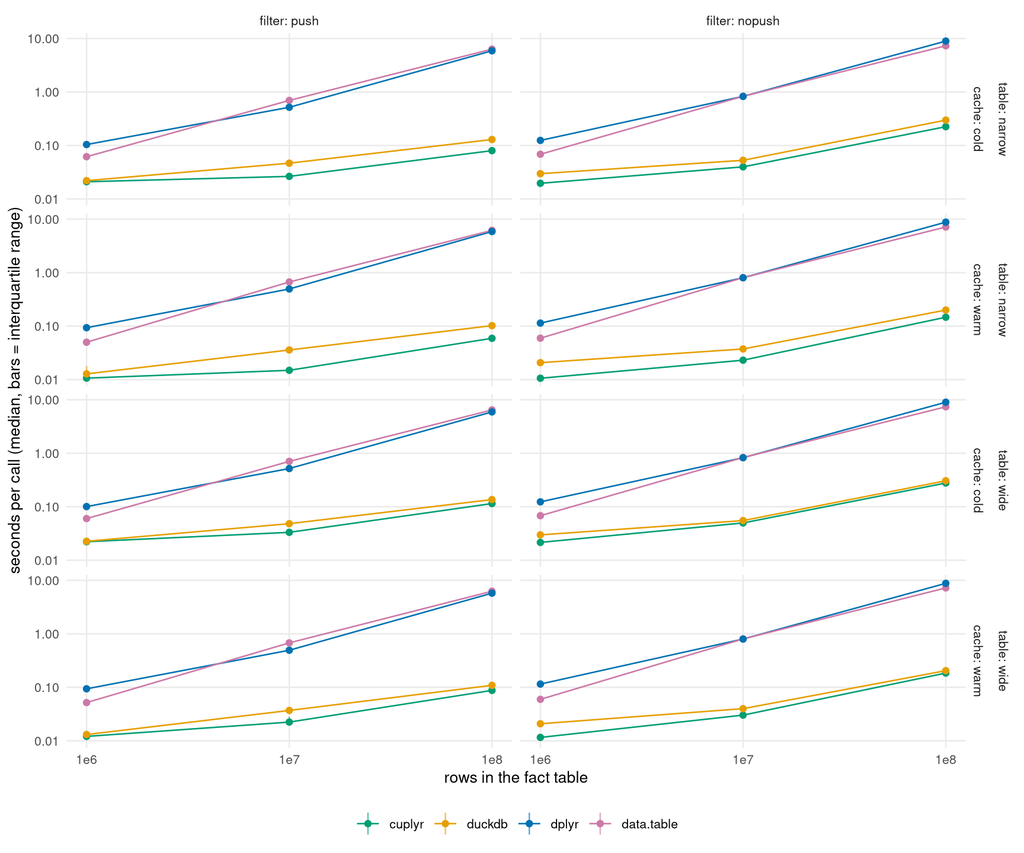

Pipeline p1: filter, mutate, group by store and channel, summarise (4000 groups)

### Pipeline `p2`

filter, mutate, join to the store dimension, group by region and channel, summarise (40 groups). Warm cache:

| filter | table | rows | cuplyr | duckdb | dplyr | data.table |
| --- | --- | --- | --- | --- | --- | --- |
| push | narrow | 1e6 | 0.0153 (0.0151-0.0157) n=15 | **0.0116 (0.0114-0.013) n=15** | 0.0684 (0.068-0.0707) n=15 | 0.0693 (0.0674-0.0709) n=15 |
| push | narrow | 1e7 | **0.0235 (0.023-0.0279) n=10** | 0.0324 (0.0322-0.0333) n=10 | 0.611 (0.594-0.664) n=10 | 0.78 (0.734-0.787) n=10 |
| push | narrow | 1e8 | 0.143 (0.138-0.145) n=5 | **0.0765 (0.0761-0.0778) n=5** | 7.39 (7.37-7.41) n=5 | 7 (6.92-7.01) n=5 |
| push | wide | 1e6 | 0.0162 (0.0157-0.0171) n=15 | **0.0121 (0.0117-0.0133) n=15** | 0.0698 (0.0688-0.075) n=15 | 0.0721 (0.071-0.0752) n=15 |
| push | wide | 1e7 | **0.0308 (0.03-0.0326) n=10** | 0.0329 (0.0328-0.0335) n=10 | 0.609 (0.597-0.664) n=10 | 0.771 (0.736-0.775) n=10 |
| push | wide | 1e8 | 0.167 (0.166-0.176) n=5 | **0.0838 (0.0831-0.0849) n=5** | 7.42 (7.38-7.49) n=5 | 7.01 (7-7.16) n=5 |
| nopush | narrow | 1e6 | **0.015 (0.0148-0.0152) n=15** | 0.0207 (0.0198-0.0223) n=15 | 0.103 (0.101-0.104) n=15 | 0.0732 (0.0721-0.0799) n=15 |
| nopush | narrow | 1e7 | **0.0315 (0.0313-0.0335) n=10** | 0.0379 (0.0351-0.0393) n=10 | 0.909 (0.907-0.928) n=10 | 0.878 (0.874-0.893) n=10 |
| nopush | narrow | 1e8 | 0.228 (0.226-0.235) n=5 | **0.187 (0.187-0.188) n=5** | 10.5 (10.4-10.5) n=5 | 7.91 (7.85-7.97) n=5 |
| nopush | wide | 1e6 | **0.0165 (0.016-0.0175) n=15** | 0.0208 (0.0203-0.0215) n=15 | 0.104 (0.103-0.106) n=15 | 0.0752 (0.0736-0.0788) n=15 |
| nopush | wide | 1e7 | **0.0389 (0.0386-0.0394) n=10** | 0.04 (0.0354-0.0409) n=10 | 0.917 (0.904-0.93) n=10 | 0.871 (0.865-0.886) n=10 |
| nopush | wide | 1e8 | 0.262 (0.261-0.275) n=5 | **0.19 (0.189-0.191) n=5** | 10.4 (10.4-10.5) n=5 | 7.88 (7.86-8.02) n=5 |

Cold cache:

| filter | table | rows | cuplyr | duckdb | dplyr | data.table |
| --- | --- | --- | --- | --- | --- | --- |
| push | narrow | 1e6 | 0.0247 (0.0245-0.0269) n=15 | **0.0216 (0.0213-0.022) n=15** | 0.0823 (0.0795-0.0838) n=15 | 0.0791 (0.0786-0.0802) n=15 |
| push | narrow | 1e7 | **0.035 (0.0347-0.0352) n=10** | 0.0442 (0.0429-0.0459) n=10 | 0.636 (0.625-0.681) n=10 | 0.798 (0.766-0.81) n=10 |
| push | narrow | 1e8 | 0.168 (0.168-0.173) n=5 | **0.106 (0.106-0.11) n=5** | 7.52 (7.51-7.57) n=5 | 7.12 (7.05-7.14) n=5 |
| push | wide | 1e6 | 0.0266 (0.0264-0.027) n=15 | **0.0221 (0.0216-0.0224) n=15** | 0.0788 (0.0781-0.0835) n=15 | 0.079 (0.078-0.0809) n=15 |
| push | wide | 1e7 | **0.0425 (0.0419-0.0464) n=10** | 0.0443 (0.0438-0.0452) n=10 | 0.639 (0.623-0.705) n=10 | 0.801 (0.778-0.812) n=10 |
| push | wide | 1e8 | 0.196 (0.194-0.199) n=5 | **0.113 (0.11-0.116) n=5** | 7.56 (7.51-7.69) n=5 | 7.26 (7.24-7.28) n=5 |
| nopush | narrow | 1e6 | **0.0237 (0.0235-0.0242) n=15** | 0.0297 (0.0294-0.0301) n=15 | 0.113 (0.11-0.114) n=15 | 0.0839 (0.0833-0.0866) n=15 |
| nopush | narrow | 1e7 | **0.0487 (0.0481-0.0495) n=10** | 0.0504 (0.0496-0.0526) n=10 | 0.945 (0.942-0.951) n=10 | 0.909 (0.893-0.919) n=10 |
| nopush | narrow | 1e8 | 0.31 (0.307-0.312) n=5 | **0.281 (0.28-0.284) n=5** | 10.5 (10.5-10.6) n=5 | 7.97 (7.92-7.98) n=5 |
| nopush | wide | 1e6 | **0.0252 (0.0247-0.0257) n=15** | 0.0299 (0.0296-0.0306) n=15 | 0.111 (0.108-0.113) n=15 | 0.0829 (0.0826-0.0841) n=15 |
| nopush | wide | 1e7 | 0.0577 (0.0568-0.0591) n=10 | **0.0542 (0.0528-0.057) n=10** | 0.934 (0.928-0.951) n=10 | 0.908 (0.896-0.922) n=10 |
| nopush | wide | 1e8 | 0.352 (0.351-0.358) n=5 | **0.293 (0.292-0.295) n=5** | 10.7 (10.6-10.7) n=5 | 8.09 (8-8.12) n=5 |

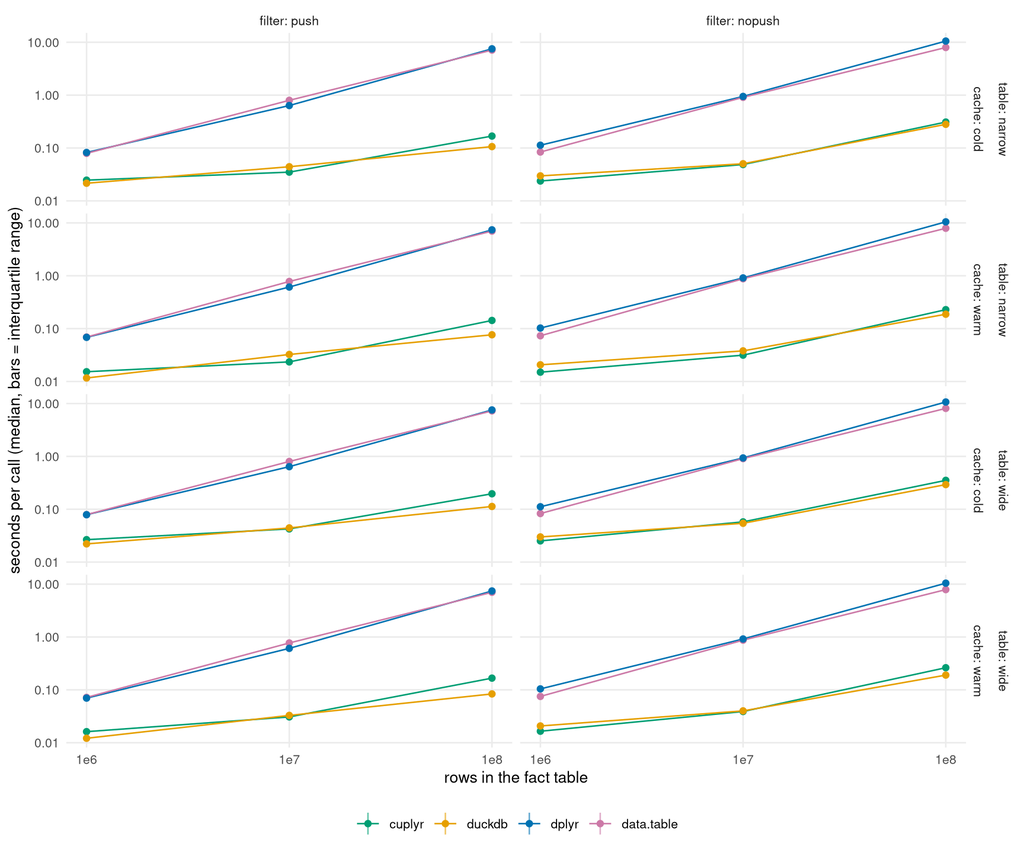

Pipeline p2: filter, mutate, join to the store dimension, group by region and channel, summarise (40 groups)

### Pipeline `p3`

filter, mutate, group by product, sum the revenue, keep the top 10 (ties kept). Warm cache:

| filter | table | rows | cuplyr | duckdb | dplyr | data.table |
| --- | --- | --- | --- | --- | --- | --- |
| push | narrow | 1e6 | **0.00917 (0.00901-0.00999) n=15** | 0.0201 (0.0193-0.0207) n=15 | 0.295 (0.291-0.299) n=15 | 0.0237 (0.0221-0.0243) n=15 |
| push | narrow | 1e7 | **0.0132 (0.0132-0.016) n=10** | 0.0457 (0.0452-0.0479) n=10 | 0.538 (0.524-0.547) n=10 | 0.308 (0.305-0.31) n=10 |
| push | narrow | 1e8 | **0.0483 (0.0474-0.0515) n=5** | 0.209 (0.208-0.211) n=5 | 2.85 (2.84-2.95) n=5 | 1.74 (1.73-1.75) n=5 |
| push | wide | 1e6 | **0.0106 (0.0105-0.0109) n=15** | 0.02 (0.0195-0.0208) n=15 | 0.299 (0.294-0.301) n=15 | 0.0237 (0.0227-0.0241) n=15 |
| push | wide | 1e7 | **0.0196 (0.0194-0.0212) n=10** | 0.0474 (0.0467-0.049) n=10 | 0.538 (0.523-0.539) n=10 | 0.301 (0.301-0.314) n=10 |
| push | wide | 1e8 | **0.0793 (0.0783-0.0844) n=5** | 0.211 (0.208-0.211) n=5 | 2.86 (2.85-2.95) n=5 | 1.73 (1.72-1.76) n=5 |
| nopush | narrow | 1e6 | **0.00966 (0.00959-0.00989) n=15** | 0.0283 (0.0276-0.0289) n=15 | 0.344 (0.339-0.352) n=15 | 0.0604 (0.0596-0.0608) n=15 |
| nopush | narrow | 1e7 | **0.0246 (0.0233-0.0277) n=10** | 0.054 (0.0534-0.0568) n=10 | 1.03 (1-1.08) n=10 | 0.809 (0.804-0.832) n=10 |
| nopush | narrow | 1e8 | **0.156 (0.155-0.162) n=5** | 0.34 (0.332-0.342) n=5 | 8.69 (8.67-8.73) n=5 | 7.13 (7.11-7.16) n=5 |
| nopush | wide | 1e6 | **0.0112 (0.011-0.0134) n=15** | 0.0294 (0.0286-0.0336) n=15 | 0.346 (0.343-0.353) n=15 | 0.0616 (0.0594-0.0622) n=15 |
| nopush | wide | 1e7 | **0.0307 (0.0301-0.0312) n=10** | 0.0571 (0.0557-0.0587) n=10 | 1.02 (1-1.08) n=10 | 0.812 (0.801-0.83) n=10 |
| nopush | wide | 1e8 | **0.198 (0.188-0.2) n=5** | 0.338 (0.333-0.34) n=5 | 8.69 (8.67-8.75) n=5 | 7.18 (7.15-7.24) n=5 |

Cold cache:

| filter | table | rows | cuplyr | duckdb | dplyr | data.table |
| --- | --- | --- | --- | --- | --- | --- |
| push | narrow | 1e6 | **0.0191 (0.0187-0.0193) n=15** | 0.0296 (0.029-0.0306) n=15 | 0.307 (0.304-0.311) n=15 | 0.0345 (0.0325-0.0351) n=15 |
| push | narrow | 1e7 | **0.0265 (0.0263-0.0287) n=10** | 0.0573 (0.0567-0.0586) n=10 | 0.569 (0.56-0.615) n=10 | 0.335 (0.331-0.341) n=10 |
| push | narrow | 1e8 | **0.081 (0.0808-0.0819) n=5** | 0.244 (0.241-0.244) n=5 | 3.01 (3-3.06) n=5 | 1.91 (1.9-1.92) n=5 |
| push | wide | 1e6 | **0.0205 (0.0204-0.0206) n=15** | 0.0308 (0.03-0.0316) n=15 | 0.307 (0.304-0.31) n=15 | 0.0349 (0.0331-0.0351) n=15 |
| push | wide | 1e7 | **0.0334 (0.0329-0.0364) n=10** | 0.0584 (0.0571-0.0588) n=10 | 0.558 (0.554-0.57) n=10 | 0.341 (0.338-0.348) n=10 |
| push | wide | 1e8 | **0.117 (0.115-0.121) n=5** | 0.267 (0.258-0.269) n=5 | 3.06 (3.05-3.07) n=5 | 1.97 (1.93-1.99) n=5 |
| nopush | narrow | 1e6 | **0.0195 (0.0191-0.0197) n=15** | 0.0381 (0.0371-0.0389) n=15 | 0.35 (0.349-0.358) n=15 | 0.0719 (0.07-0.0724) n=15 |
| nopush | narrow | 1e7 | **0.0437 (0.0432-0.0443) n=10** | 0.073 (0.0724-0.0755) n=10 | 1.04 (1.02-1.12) n=10 | 0.835 (0.834-0.844) n=10 |
| nopush | narrow | 1e8 | **0.277 (0.275-0.284) n=5** | 0.46 (0.456-0.47) n=5 | 8.87 (8.85-8.9) n=5 | 7.34 (7.19-7.35) n=5 |
| nopush | wide | 1e6 | **0.0211 (0.0209-0.0219) n=15** | 0.0379 (0.0373-0.039) n=15 | 0.348 (0.347-0.357) n=15 | 0.0709 (0.0694-0.0714) n=15 |
| nopush | wide | 1e7 | **0.0555 (0.0546-0.056) n=10** | 0.072 (0.0686-0.0755) n=10 | 1.06 (1.04-1.11) n=10 | 0.848 (0.843-0.859) n=10 |
| nopush | wide | 1e8 | **0.356 (0.352-0.357) n=5** | 0.485 (0.475-0.507) n=5 | 9.06 (9.05-9.09) n=5 | 7.48 (7.4-7.51) n=5 |

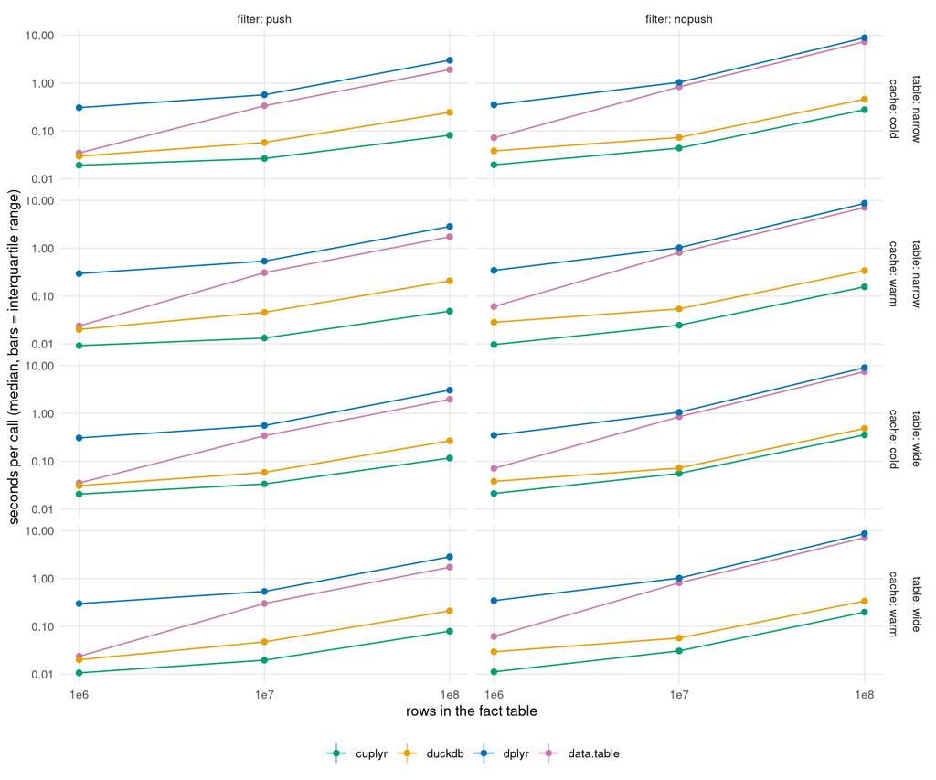

Pipeline p3: filter, mutate, group by product, sum the revenue, keep the top 10 (ties kept)

## Where cuplyr wins and loses

### Overall

cuplyr has the lowest median in 59 of the 72 cells where it and another engine both have quiet reps (30 of 36 warm, 29 of 36 cold). cuplyr’s median is 0.23 to 1.99 times the fastest other engine’s, over the cells where all of them have quiet reps. There is no combination of size, cache state and filter in which cuplyr has the lowest median in fewer than half of its cells. In the cells it loses, the fastest engine is duckdb (13). By pipeline, the cells in which cuplyr is not the fastest are p2 (13 of its 24 cells). With the pushed filter at 1e8 rows (narrow table, warm cache), the join pipeline p2 takes 2.4 times the time of p1 in cuplyr and 0.7 times in DuckDB.

| rows | cache | filter | cells | cuplyr fastest | median ratio to the best other | worst ratio |
| --- | --- | --- | --- | --- | --- | --- |
| 1e6 | cold | push | 6 | 4 | 0.97 | 1.20 |
| 1e6 | cold | nopush | 6 | 6 | 0.69 | 0.84 |
| 1e6 | warm | push | 6 | 4 | 0.88 | 1.33 |
| 1e6 | warm | nopush | 6 | 6 | 0.53 | 0.80 |
| 1e7 | cold | push | 6 | 6 | 0.63 | 0.96 |
| 1e7 | cold | nopush | 6 | 5 | 0.84 | 1.06 |
| 1e7 | warm | push | 6 | 6 | 0.51 | 0.94 |
| 1e7 | warm | nopush | 6 | 6 | 0.69 | 0.97 |
| 1e8 | cold | push | 6 | 4 | 0.73 | 1.74 |
| 1e8 | cold | nopush | 6 | 4 | 0.83 | 1.20 |
| 1e8 | warm | push | 6 | 4 | 0.69 | 1.99 |
| 1e8 | warm | nopush | 6 | 4 | 0.82 | 1.38 |

The results are small (at most 4000 rows), so bringing them to R costs little in every engine; what cuplyr pays for is the file read and the GPU’s start-up, not the transfer of the answer.

### Pushdown

| variant | table | rows | columns read | row groups kept | rows read | pushed |
| --- | --- | --- | --- | --- | --- | --- |
| p1_nopush | narrow | 1e6 | 5 of 8 | all 1 | 100% | none |
| p1_nopush | narrow | 1e7 | 5 of 8 | all 10 | 100% | none |
| p1_nopush | narrow | 1e8 | 5 of 8 | all 96 | 100% | none |
| p1_nopush | wide | 1e6 | 5 of 40 | all 1 | 100% | none |
| p1_nopush | wide | 1e7 | 5 of 40 | all 10 | 100% | none |
| p1_nopush | wide | 1e8 | 5 of 40 | all 96 | 100% | none |
| p1_push | narrow | 1e6 | 6 of 8 | 1 of 1 | 19% | day >= 2024-01-01 & qty >= 2 |
| p1_push | narrow | 1e7 | 6 of 8 | 3 of 10 | 19% | day >= 2024-01-01 & qty >= 2 |
| p1_push | narrow | 1e8 | 6 of 8 | 20 of 96 | 19% | day >= 2024-01-01 & qty >= 2 |
| p1_push | wide | 1e6 | 6 of 40 | 1 of 1 | 19% | day >= 2024-01-01 & qty >= 2 |
| p1_push | wide | 1e7 | 6 of 40 | 3 of 10 | 19% | day >= 2024-01-01 & qty >= 2 |
| p1_push | wide | 1e8 | 6 of 40 | 20 of 96 | 19% | day >= 2024-01-01 & qty >= 2 |
| p3_nopush | narrow | 1e6 | 5 of 8 | all 1 | 100% | none |
| p3_nopush | narrow | 1e7 | 5 of 8 | all 10 | 100% | none |
| p3_nopush | narrow | 1e8 | 5 of 8 | all 96 | 100% | none |
| p3_nopush | wide | 1e6 | 5 of 40 | all 1 | 100% | none |
| p3_nopush | wide | 1e7 | 5 of 40 | all 10 | 100% | none |
| p3_nopush | wide | 1e8 | 5 of 40 | all 96 | 100% | none |
| p3_push | narrow | 1e6 | 5 of 8 | 1 of 1 | 19% | day >= 2024-01-01 & qty >= 2 |
| p3_push | narrow | 1e7 | 5 of 8 | 3 of 10 | 19% | day >= 2024-01-01 & qty >= 2 |
| p3_push | narrow | 1e8 | 5 of 8 | 20 of 96 | 19% | day >= 2024-01-01 & qty >= 2 |
| p3_push | wide | 1e6 | 5 of 40 | 1 of 1 | 19% | day >= 2024-01-01 & qty >= 2 |
| p3_push | wide | 1e7 | 5 of 40 | 3 of 10 | 19% | day >= 2024-01-01 & qty >= 2 |
| p3_push | wide | 1e8 | 5 of 40 | 20 of 96 | 19% | day >= 2024-01-01 & qty >= 2 |

The table is what `parquet_last_read()` reported after each cuplyr check run of the fact file: the columns and row groups the reader was asked for, and the filters pushed into the scan. The second pipeline is not listed, because after a join the last read reported is the dimension file, not the fact file. At 1e8 rows (narrow table, warm cache, first pipeline) the pushed filter makes cuplyr read 20 of 96 row groups and 19% of the rows, against 100% of the rows for the other filter. The time of the pushed variant relative to the other is cuplyr 0.40, duckdb 0.51, dplyr 0.67, data.table 0.87. cuplyr’s ratio is clearly lower than that of dplyr and data.table, which decode every row before they filter, so the row groups skipped by the pushed filter are a likely reason for part of cuplyr’s gain between the two filters; the filters also differ in cost for the CPU engines, which their ratios show. DuckDB’s ratio is lower as well, which would fit its skipping row groups by their statistics too (not checked here).

### Projection on the wide table

At 1e8 rows with the nopush filter and a warm cache, the wide table has 40 columns against 8; every engine is asked for the same 5 columns. cuplyr is 1.26 times slower on the wide table, duckdb does not slow down on the wide table, dplyr does not slow down on the wide table and data.table does not slow down on the wide table. cuplyr reads 5 of the 40 columns of the wide file (see the table above), and DuckDB and arrow are given the same column list.

### Cold cache

At 1e8 rows (narrow table, nopush filter, first pipeline) the cold call takes 1.5 times the warm call for cuplyr, 1.5 times the warm call for duckdb, 1.0 times the warm call for dplyr, 1.0 times the warm call for data.table.

### The first call of a cell

Within a cell, the first call (rep 0, not in the medians) takes 1.3 times the median for cuplyr, 1.0 times the median for duckdb, 1.0 times the median for dplyr, 1.0 times the median for data.table (median over cells). The fresh-process first calls are in the next section.

### Memory

No cell ran out of memory.

## First call

Each engine and variant ran in a fresh R process at 1e7 rows (narrow table, warm cache): the packages were loaded first (`load_secs`; for cuplyr that is `pkgload::load_all()` of the checkout, which is not what an installed package would pay), DuckDB’s connection was opened, and then the calls ran one after another, each timed separately. A call is slow when it takes more than three times the median of the later half of the calls.

| engine | call 1 | call 2 | call 3 | call 4 | call 5 | call 6 | call 7 | call 8 | load (s) |
| --- | --- | --- | --- | --- | --- | --- | --- | --- | --- |
| cuplyr | 0.718 | 0.676 | 0.0144 | 0.0138 | 0.0139 | 0.0137 | 0.0137 | 0.0137 | 0.71 |
| duckdb | 0.0445 | 0.0403 | 0.0353 | 0.0349 | 0.0352 | 0.0346 | 0.0351 | 0.0366 | 0.151 |
| dplyr | 0.661 | 0.525 | 0.517 | 0.537 | 0.507 | 0.515 | 0.504 | 0.513 | 0.243 |
| data.table | 0.745 | 0.527 | 0.531 | 0.523 | 0.584 | 0.503 | 0.522 | 0.52 | 0.193 |

| engine | variants with a slow start | slow calls (median) | first call, median (s) | later calls, median (s) |
| --- | --- | --- | --- | --- |
| cuplyr | 6 | 2 | 0.716 | 0.0219 |
| duckdb | 0 | 0 | 0.0459 | 0.0374 |
| dplyr | 0 | 0 | 0.847 | 0.733 |
| data.table | 0 | 0 | 0.809 | 0.599 |

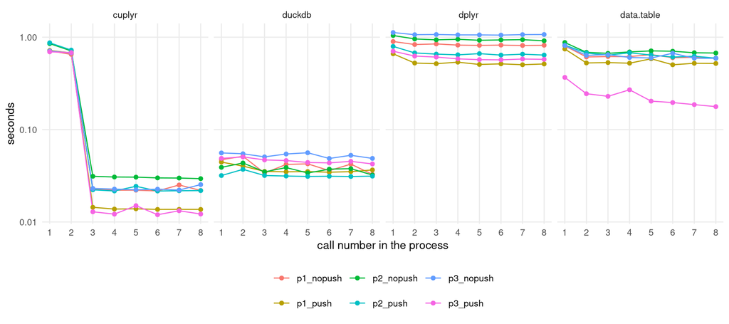

Seconds per call in a fresh process, by call number and variant

## Findings

### cuplyr’s first calls in a fresh process

A repro in a fresh R process (the file is the benchmark’s narrow table from `pp_gen_fact()`):

```r
pkgload::load_all("."); library(dplyr)
f <- "fact-narrow-10000000.parquet"
run <- function() {
  read_parquet_gpu(f) |>
    filter(day >= as.Date("2024-01-01"), qty >= 2L) |>
    mutate(revenue = price * qty * (1 - discount)) |>
    group_by(store, channel) |>
    summarise(n = n(), revenue = sum(revenue, na.rm = TRUE), avg_price = mean(price),
              max_qty = max(qty), .groups = "drop") |>
    collect()
}
for (i in 1:5) print(system.time(run())[["elapsed"]])
```

### Wrong results and errors

None: every engine matched the reference in every cell.

### Memory

No cell ran out of memory. In cuplyr this is a classed `cuplyr_error_gpu_oom` error; it is recorded as “does not fit”, not retried.

## Caveats

- cuplyr runs with libcudf’s debug stream pool switched on, which its `.onLoad` does by default since the second attempt at F85 (`LIBCUDF_USE_DEBUG_STREAM_POOL`). Every cuplyr number here includes that setting.
- F128 (the memory resource), F86 (transfers) and F87 (chunked streaming) may change cuplyr’s numbers; this is a first set of measurements, to be repeated after they land.
- F123 ran on the same machine and GPU. The harness waited for quiet and re-ran busy reps (4 calls were dropped); a load below the threshold still goes into the numbers.
- The data are sorted by date, which favours date pruning for any engine that uses row group statistics. Unsorted data would show less of the pushdown gap.
- DuckDB’s local file caching is off by default (`cache_local_files = false`), so for DuckDB warm and cold mean the operating system’s page cache, as for the others.
- One machine, one GPU, synthetic data, one codec (snappy), and the default thread counts of every engine; other settings or hardware will move the ratios.